# Assignment 2

Derek Rouch

LLO 8200

Introduction to Data Science

September 1, 2019

## Setting up R

To begin, I cleared my Global Environment and get the necessary libraries: `knitr`, `tidyverse`, `plotly`, and `Metrics`.

```r
## Clear environment
rm(list=ls())

## Get libraries
library(knitr)
knitr::opts_chunk$set(echo = TRUE)
library(tidyverse)
```

```r
library(plotly)
library(Metrics)
```

Then, I loaded the `pd.Rdata` dataset, as well as the `pd_lab_explain.Rdata` codebook to decode the column headings.

```r
## Load in the county-level data
load("/Users/derekrouch/Documents/GitHub/data-science/pd.Rdata")

## Load the variable descriptions
load("/Users/derekrouch/Documents/GitHub/data-science/pd_lab_explain.Rdata")
```

## 1) Calculate the mean of the outcome.

With the data loaded, I was able to pipe it to the `summarize` function to view the unconditional average of the home ownership rate variable, `homeown_rate`, which I found using the `mean` function.

```r
## Unconditional average
pd%>%summarize(mean_homeown_rate=mean(homeown_rate,na.rm=TRUE))
```

```
## # A tibble: 1 x 1
##   mean_homeown_rate
##               <dbl>
## 1              72.7
```

## 2) Use your mean as a prediction: Create a new variable that consists of the mean of the outcome.

To create a new variable, I piped the data to the `mutate` function, and added `mean_homeown_rate` as a new column in my original `pd` dataset.

```r
##Unconditional average as a predictor
pd <- pd%>%mutate(mean_homeown_rate=mean(homeown_rate,na.rm=TRUE))
```

## 3) Calculate a summary measure of the errors for each observation—the difference between your prediction and the outcome.

Now that every observation in my dataset had the same value for `mean_homeown_rate`, I could calculate the error for each observation—that is, how far each county’s home ownership rate is from the mean of 72.7%.

To accomplish this, I subtracted the `mean_homeown_rate` from each individual county’s `homeown_rate`. I named this difference `error_uncond`. Counties with positive error values have home ownership rates higher than the national average, while counties with negative error values have home ownership rates below that of the national average.

```r
## Calculating the error term
pd <- pd%>%mutate(error_uncond=homeown_rate-mean_homeown_rate)
```

To see how far off this unconditional predication is, I calculated the root mean squared error, using the `rmse` function.

```r
## Calculating the root mean squared error
rmse_uncond_mean <- rmse(pd$homeown_rate,pd$mean_homeown_rate)

## Calling the RMSE
rmse_uncond_mean
```

```
## [1] 7.653637
```

This root mean squared error tells me that the unconditional mean is off by 7.65 percent.

## 4) Calculate the mean of the outcome at levels of a predictor variable.

In hopes of making a better estimate, I wanted to determine a predictor variable. First, I examined the table. However, with 57 variables (the original 55 plus my 2 new ones), it felt like I would be shooting in the dark, so I wanted a way of enhancing my guesswork.

I knew this would require venturing to the far frontiers of my *R* knowledge, but I felt that there was no corner Google and StackExchange couldn’t get me out of, so I ventured on.

*I apologize in advance if the following process is an affront to real statistical analysis.*

My first decision was to create a correlation matrix.

To do this, I first needed to make sure that the data was in numeric form. I used `sapply` to determine the class of each variable.

```r
## Determine each variable's class
sapply(pd, class)
```

```
##                   fips                pop2013           pop2010_base
##            "character"              "integer"              "integer"
##           popchange_pc                pop2010                  popu5
##              "numeric"              "integer"              "numeric"
##                 popu18                 pop65p              female_pc
##              "numeric"              "numeric"              "numeric"
##               white_pc               black_pc              am_ind_pc
##              "numeric"              "numeric"              "numeric"
##               asian_pc           hawaii_pi_pc        twomore_race_pc
##              "numeric"              "numeric"              "numeric"
##            hispanic_pc  white_non_hispanic_pc          same_house_pc
##              "numeric"              "numeric"              "numeric"
##        foreign_born_pc      other_eng_home_pc             hs_grad_pc
##              "numeric"              "numeric"              "numeric"
##           coll_grad_pc               veterans            travel_time
##              "numeric"              "integer"              "numeric"
##          housing_units           homeown_rate       house_unit_multi
##              "integer"              "numeric"              "numeric"
##        median_home_val             households          person_per_hh
##              "integer"              "integer"              "numeric"
##         per_capita_inc          median_hh_inc  persons_below_poverty
##              "integer"              "integer"              "numeric"
##             pv_nonfarm      pv_nonfarm_employ   pv_nonfarm_employ_ch
##              "integer"              "integer"              "numeric"
##        nonemployer_est                  firms     firms_black_own_pc
##              "integer"              "integer"              "numeric"
##     firms_amind_own_pc     firms_asian_own_pc firms_hawaii_pi_own_pc
##              "numeric"              "numeric"              "numeric"
##  firms_hispanic_own_pc    firms_female_own_pc       manufacture_ship
##              "numeric"              "numeric"              "numeric"
##              wholesale                 retail          retail_percap
##              "numeric"              "numeric"              "integer"
##            hospitality           bldg_permits              land_area
##              "integer"              "integer"              "numeric"
##         pop_per_square                 county         percapinc.2010
##              "numeric"            "character"              "numeric"
##         percapinc.2012      mean_homeown_rate           error_uncond
##              "numeric"              "numeric"              "numeric"
```

This showed me that the dataset’s variables `fips` and `county` were stored as text, so I used `subset` to remove those columns and create a new, numeric-only dataset—which I named `pd_num_only`.

```r
## Create a subset of the data, consisting of only numeric variables
pd_num_only <- subset(pd, select = -c(fips, county))
```

With this new dataset, I was finally able to create my correlation matrix, which I named `cor_matrix`. Since I am only concerned with `homeown_rate` correlations, I made a subset of the matrix to include only that variable.

```r
## Create a correlation matrix, rounded to two decimal places
cor_matrix <- cor(pd_num_only)
round(cor_matrix, 2)

## Remove every column except `homeown_rate` in the matrix
cor_homeown_rate <- subset(cor_matrix, select = c(homeown_rate))
```

By viewing and sorting the new subset, I found two variables that showed some promise for predictive value. `house_unit_multi` (the percent of housing units in multi-unit structures) had a correlation coefficient of -0.68, and `same_house_pc` (the perecent living in the same house for one or more years) had a correlation coefficient of 0.57.

Although negatively correlated, `house_unit_multi` had the strongest magnitude and was therefore my choice for predictor variable.

I then broke up `house_unit_multi` into four levels using the `ntile` function, and added it as a variable using `mutate`.

```r
## Create a variable for quartiles of % housing units in multi-unit structures
pd<-pd%>%mutate(house_unit_multi_level=ntile(house_unit_multi,4))

## Check for evenl distribution across levels
table(pd$house_unit_multi_level)
```

```
##
##   1   2   3   4
## 772 772 772 772
```

```r
## View house_unit_multi_level for each county
pd%>%select(county,house_unit_multi,house_unit_multi_level)%>%View()
```

From here, I grouped the data by `house_unit_multi_level`, caluclated the `pred_homeown_rate` for each level, and ranked them in descending order (i.e., higher predicted home ownership rates on top)

```r
##Group by predictor level
  pd<-pd%>%group_by(house_unit_multi_level)%>%
  ##Calculate mean at each level of predictor
  mutate(pred_homeown_rate=mean(homeown_rate))%>%
  ## Ungroup
  ungroup()%>%
  #Rank by prediction, with ties sorted randomly
  mutate(pred_homeown_rate_rank=rank(-pred_homeown_rate,ties.method="random"))
```

## 5) Use these conditional means as a prediction: for every county, use the conditional mean to provide a ‘’best guess” as to that county’s level of the outcome.

Finally, I could view the counties and sort them by `pred_homeown_rate_rank`.

```r
## View new pred_homeown_rate by county
pd%>%select(county,house_unit_multi,house_unit_multi_level,pred_homeown_rate, pred_homeown_rate_rank)%>%View()
```

To visualize this as a plot, I used the `ggplot` function.

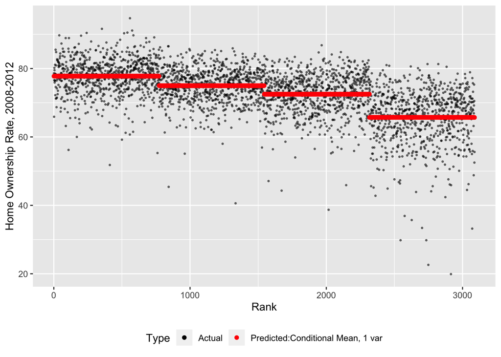

```r
## Plotting
gg<-ggplot(data=pd,aes(x=pred_homeown_rate_rank,y=homeown_rate,color="Actual"))

## Stylizing the Plot
gg<-gg+geom_point(alpha=.5,size=.5)
gg<-gg+geom_point(aes(x=pred_homeown_rate_rank,y=pred_homeown_rate,color="Predicted:Conditional Mean, 1 var"))
gg<-gg+ scale_color_manual("Type",values=c("Predicted:Conditional Mean, 1 var"="red","Actual"="black"))
gg<-gg+theme(legend.position="bottom")
gg<-gg+xlab("Rank")+ylab("Home Ownership Rate, 2008-2012")

## Calling the plot
gg
```

## 6) Calculate a summary measure of the error in your predictions.

With my new `pred_homeown_rate` variable, I could now calculate the conditional error for each observation—that is, how far each county’s home ownership rate is from the mean of 72.7%, when predicted by `house_unit_multi_level`.

To accomplish this, I subtracted the `mean_homeown_rate` from each individual county’s `pred_homeown_rate`. I named this difference `error_cond`. Once again, counties with positive error values have home ownership rates higher than the national average, while counties with negative error values have home ownership rates below that of the national average.

```r
## Calculating the error term
pd <- pd%>%mutate(error_cond=pred_homeown_rate-mean_homeown_rate)
```

As I did earlier, I also calculated the root mean squared error to see how far these values were off.

```r
## Calculating the root mean squared error based on house_unit_multi_level
rmse_cond_mean <- rmse(pd$pred_homeown_rate,pd$mean_homeown_rate)

## Calling the RMSE
rmse_cond_mean
```

```
## [1] 4.47162
```

To see what how much adding the `house_unit_multi_level` predictor variable improved my RMSE, I subtracted the two values.

```r
## Calculating the difference between rmse_uncond and rmse_cond
rmse_difference <- rmse_uncond_mean-rmse_cond_mean

## Calling the RMSE difference, rounded to two decimal places
round(rmse_difference, 2)
```

```
## [1] 3.18
```

```r
## Calculating the percentage improvement
rmse_percent_improved <- (rmse_difference/rmse_uncond_mean)*100

## Calling the RMSE prcent improvement, rounded to two decimal places
round(rmse_percent_improved, 2)
```

```
## [1] 41.58
```